# 12-tcell-cd4-cd8-trajectory

Bicna Song

2026-07-15

This module extends the T-cell trajectory analysis by first separating CD4-like and CD8-like cells using marker expression and ScGate support. The marker-classified T-cell object is annotated with ProjecTILs using the mouse TIL reference before clean CD4-like and CD8-like objects are clustered and annotated separately. Slingshot is then run on condition-specific CD4-like and CD8-like subsets.

## Setup

```r
suppressPackageStartupMessages({
  library(rprojroot)
  library(dplyr)
  library(purrr)
  library(Seurat)
  library(SingleCellExperiment)
  library(SeuratExtend)
  library(ggplot2)
  library(patchwork)
})

root_dir <- find_root(has_dir(".git"))
data_dir <- file.path(root_dir, "data", "v5")
analysis_dir <- file.path(root_dir, "analyses", "downstream-analyses")
results_dir <- file.path(analysis_dir, "results", "tcell")
plot_dir <- file.path(analysis_dir, "plots", "tcell")

source(file.path(root_dir, "figures", "theme.R"))
source(file.path(analysis_dir, "util", "trajectory_helpers.R"))
source(file.path(analysis_dir, "util", "tcell_cd4_cd8_trajectory_helpers.R"))

set.seed(1234)
```

## Parameters

This chunk records the input file, marker thresholds, Slingshot thresholds, and marker programs used throughout the analysis.

CD4 and CD8 marker scores are calculated from average marker expression and used to identify CD4-like and CD8-like cells. ProjecTILs labels and the naive/memory marker score are used to choose the Slingshot root cluster. Functional-state marker programs are also scored with average marker expression and kept as supporting evidence for CD4-like and CD8-like cluster annotation.

```r
input_rds <- "cart_tcell_subtypes.rds"
min_score_delta <- 0.15
min_marker_score <- 0.10
min_cells_for_slingshot <- 100
min_clusters_for_slingshot <- 3
min_cells_per_cluster <- 10

marker_programs <- list(
  CD4 = c("Cd4"),
  CD8 = c("Cd8a", "Cd8b1"),
  naive_memory = c("Tcf7", "Lef1", "Sell", "Ccr7", "Il7r"),
  activated = c("Cd69", "Il2ra", "Icos", "Tnfrsf4", "Tnfrsf9"),
  treg = c("Foxp3", "Il2ra", "Ctla4", "Tigit", "Ikzf2"),
  cytotoxic = c("Nkg7", "Gzmb", "Gzma", "Prf1", "Ifng", "Ccl5"),
  exhausted = c("Pdcd1", "Lag3", "Havcr2", "Tox", "Tigit", "Ctla4"),
  proliferating = c("Mki67", "Top2a", "Cdk1", "Ccnb1", "Ccnb2"),
  ifn_response = c("Ifit1", "Ifit3", "Isg15", "Oas1a", "Oas3", "Zbp1"),
  stress_response = c("Hspa1a", "Hspa1b", "Dnajb1", "Jun", "Fos")
)

cat("Input RDS:", input_rds, "\n")
```

```
## Input RDS: cart_tcell_subtypes.rds
```

```r
cat("Minimum CD4/CD8 score delta:", min_score_delta, "\n")
```

```
## Minimum CD4/CD8 score delta: 0.15
```

```r
cat("Minimum marker score:", min_marker_score, "\n")
```

```
## Minimum marker score: 0.1
```

```r
cat("Minimum cells for Slingshot:", min_cells_for_slingshot, "\n")
```

```
## Minimum cells for Slingshot: 100
```

```r
cat("Minimum clusters for Slingshot:", min_clusters_for_slingshot, "\n")
```

```
## Minimum clusters for Slingshot: 3
```

```r
cat("Minimum cells per Slingshot cluster:", min_cells_per_cluster, "\n")
```

```
## Minimum cells per Slingshot cluster: 10
```

## Load T-cell object

This chunk loads the renamed T-cell object and confirms that condition metadata is available for downstream pseudotime summaries.

```r
input_path <- dplyr::case_when(
  file.exists(file.path(results_dir, input_rds)) ~ file.path(results_dir, input_rds),
  file.exists(file.path(data_dir, input_rds)) ~ file.path(data_dir, input_rds),
  TRUE ~ NA_character_
)

if (is.na(input_path)) {
  stop("Input RDS was not found in results/tcell or data/v5: ", input_rds)
}

cat("Reading:", input_path, "\n")
```

```
## Reading: /home/rstudio/haydar-scrna/analyses/downstream-analyses/results/tcell/cart_tcell_subtypes.rds
```

```r
tcell_obj <- readRDS(input_path)

stopifnot("condition" %in% colnames(tcell_obj@meta.data))

if ("tcell_subtype" %in% colnames(tcell_obj@meta.data)) {
  table(tcell_obj$tcell_subtype)
  tcell_obj$previous_tcell_subtype <- tcell_obj$tcell_subtype
}

table(tcell_obj$condition)
```

```
##
##    41BB-L      B7H3 CD28-41BB  CD8-41BB      STOP     tumor
##      1196      2355       798      3071      1090       377
```

```r
condition_levels <- if (is.factor(tcell_obj$condition)) {
  levels(droplevels(tcell_obj$condition))
} else {
  sort(unique(as.character(tcell_obj$condition)))
}

cat("Conditions:", paste(condition_levels, collapse = ", "), "\n")
```

```
## Conditions: 41BB-L, B7H3, CD28-41BB, CD8-41BB, STOP, tumor
```

## CD4/CD8 marker classification

This chunk classifies cells as CD4-like, CD8-like, or ambiguous using CD4 and CD8 marker-expression scores. The marker-score summary checks whether the split captures clear CD4-like and CD8-like populations while leaving uncertain cells as ambiguous.

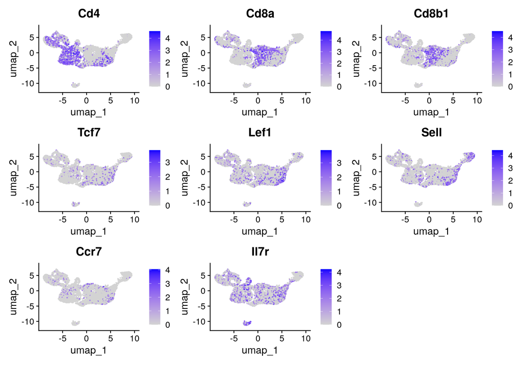

```r
tcell_obj <- classify_cd4_cd8(tcell_obj)

score_cols <- purrr::map_chr(names(marker_programs), marker_score_column) %>%
  intersect(colnames(tcell_obj@meta.data))

marker_score_summary <- tcell_obj@meta.data %>%
  dplyr::group_by(condition, cd4_cd8_marker_group) %>%
  dplyr::summarise(
    n = dplyr::n(),
    dplyr::across(
      dplyr::all_of(score_cols),
      ~ median(.x, na.rm = TRUE),
      .names = "median_{.col}"
    ),
    .groups = "drop"
  )

write.csv(
  marker_score_summary,
  file.path(results_dir, "tcell_cd4_cd8_marker_score_summary.csv"),
  row.names = FALSE
)

p_marker_feature <- FeaturePlot(
  tcell_obj,
  features = available_features(
    tcell_obj,
    c(marker_programs$CD4, marker_programs$CD8, marker_programs$naive_memory)
  ),
  reduction = "umap",
  ncol = 3
)

p_marker_group <- DimPlot(
  tcell_obj,
  reduction = "umap",
  group.by = "cd4_cd8_marker_group"
) +
  ggtitle("CD4/CD8 marker-based groups")

p_marker_scatter <- ggplot(
  tcell_obj@meta.data,
  aes(x = cd4_score, y = cd8_score, color = cd4_cd8_marker_group)
) +
  geom_point(size = 0.25, alpha = 0.45) +
  geom_abline(slope = 1, intercept = min_score_delta, linetype = "dashed", color = "grey35") +
  geom_abline(slope = 1, intercept = -min_score_delta, linetype = "dashed", color = "grey35") +
  theme_Publication() +
  labs(
    title = "CD4/CD8 marker-score split",
    x = "CD4 marker score",
    y = "CD8 marker score",
    color = "Marker group"
  )

p_marker_feature
```

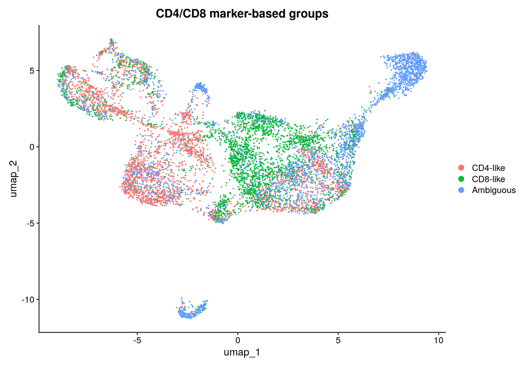

```r
p_marker_group
```

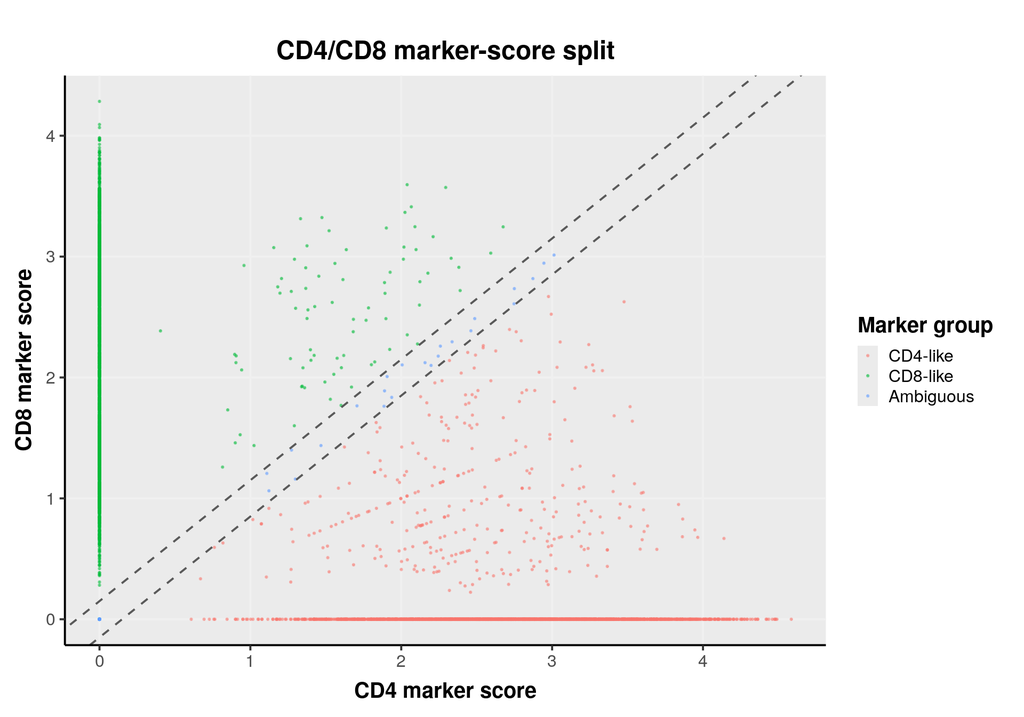

```r
p_marker_scatter
```

```r
ggsave(
  file.path(plot_dir, "tcell_cd4_cd8_marker_expression_umap.pdf"),
  plot = p_marker_feature,
  width = 10,
  height = 7,
  device = cairo_pdf
)

ggsave(
  file.path(plot_dir, "tcell_cd4_cd8_marker_groups_and_score_scatter.pdf"),
  plot = p_marker_group | p_marker_scatter,
  width = 12,
  height = 5,
  device = cairo_pdf
)
```

## ScGate CD4/CD8 support

This chunk runs generic mouse ScGate CD4T/CD8T models on the marker-classified T-cell object. ScGate is used here as supporting evidence for CD4/CD8 identity before creating the clean CD4-like and CD8-like trajectory inputs.

```r
tcell_obj <- run_scgate_cd4_cd8(tcell_obj)
```

```
## Using local version of repo scGate_models-master. If you want update it, set option force_update = TRUE
```

```
##
## ### Detected a total of 3073 pure 'Target' cells (34.58% of total)
```

```
##
## ### Detected a total of 2163 pure 'Target' cells (24.34% of total)
```

```r
scgate_marker_counts <- tcell_obj@meta.data %>%
  dplyr::count(
    condition,
    cd4_cd8_marker_group,
    scgate_cd4_cd8_group,
    name = "n"
  ) %>%
  dplyr::arrange(condition, cd4_cd8_marker_group, scgate_cd4_cd8_group)

write.csv(
  scgate_marker_counts,
  file.path(results_dir, "tcell_cd4_cd8_marker_scgate_concordance.csv"),
  row.names = FALSE
)
```

## ProjecTILs state annotation

This chunk runs ProjecTILs on the marker-classified T-cell object using the default mouse tumor-infiltrating T-cell reference. These labels are used as reference-based support for ambiguous cells, cluster annotation, and naive-like Slingshot root selection.

```r
tcell_obj <- run_projectils_annotation(tcell_obj)
```

```
## [1] "Loading Default Reference Atlas..."
## [1] "/home/rstudio/haydar-scrna/analyses/downstream-analyses/ref_TILAtlas_mouse_v1.rds"
## [1] "Loaded Custom Reference map ref_TILAtlas_mouse_v1"
##   |                                                                              |                                                                      |   0%[1] "Using assay RNA for query"
## [1] "Aligning query to reference map for batch-correction..."
##
## Projecting corrected query onto Reference PCA space
##
## Projecting corrected query onto Reference UMAP space
##   |                                                                              |======================================================================| 100%
```

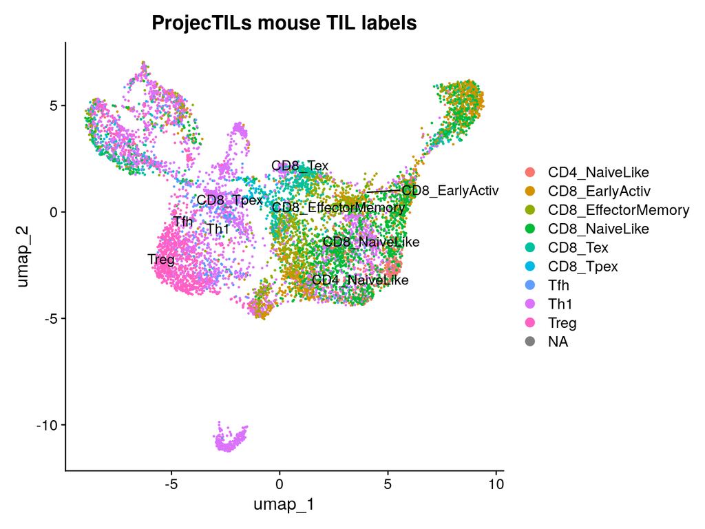

```r
projectils_counts <- tcell_obj@meta.data %>%
  dplyr::count(
    condition,
    cd4_cd8_marker_group,
    scgate_cd4_cd8_group,
    projectils_label,
    name = "n"
  ) %>%
  dplyr::arrange(condition, cd4_cd8_marker_group, scgate_cd4_cd8_group, dplyr::desc(n))

write.csv(
  projectils_counts,
  file.path(results_dir, "tcell_cd4_cd8_projectils_labels_by_group.csv"),
  row.names = FALSE
)

p_projectils <- DimPlot(
  tcell_obj,
  reduction = "umap",
  group.by = "projectils_label",
  label = TRUE,
  repel = TRUE
) +
  ggtitle("ProjecTILs mouse TIL labels")

p_projectils
```

```r
ggsave(
  file.path(plot_dir, "tcell_cd4_cd8_projectils_labels_umap.pdf"),
  plot = p_projectils,
  width = 8,
  height = 6,
  device = cairo_pdf
)
```

## Prepare clean CD4/CD8 cells

This chunk keeps cells with concordant marker-based and ScGate-supported CD4/CD8 identity and carries ProjecTILs labels into the clean CD4-like and CD8-like trajectory inputs.

```r
clean_obj <- subset(
  tcell_obj,
  subset = cd4_cd8_marker_group == scgate_cd4_cd8_group &
    cd4_cd8_marker_group %in% c("CD4-like", "CD8-like")
)

clean_obj$cd4_cd8_marker_group <- droplevels(clean_obj$cd4_cd8_marker_group)

clean_cd4_obj <- subset(clean_obj, subset = cd4_cd8_marker_group == "CD4-like")
clean_cd8_obj <- subset(clean_obj, subset = cd4_cd8_marker_group == "CD8-like")
```

## Cluster and annotate CD4-like and CD8-like cells separately

This chunk clusters the clean CD4-like and CD8-like objects once using regular PCA. The clusters are annotated with ProjecTILs, average-expression functional-state marker programs, previous T-cell subtype labels, and SingleR with both mouse references, and a compact cluster annotation table is written.

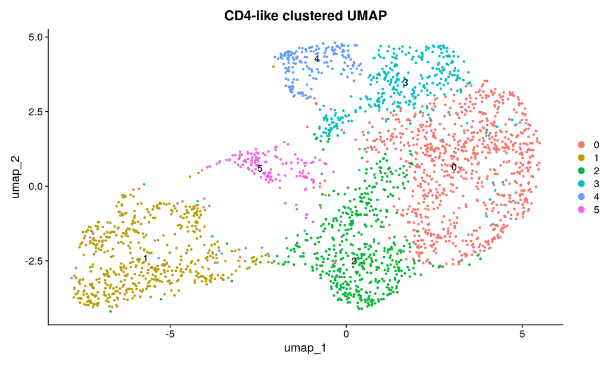

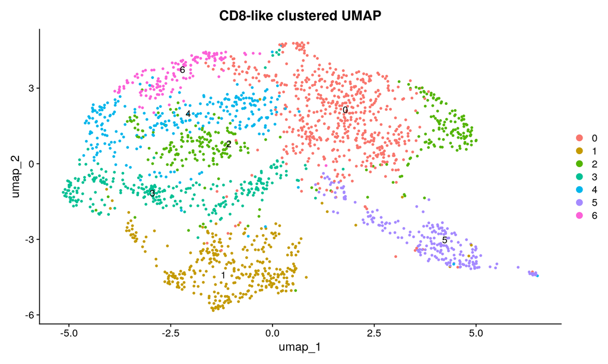

```r
compartment_objects <- list()
compartment_cluster_annotations <- list()
for (compartment in c("CD4-like", "CD8-like")) {
  obj_compartment <- if (compartment == "CD4-like") clean_cd4_obj else clean_cd8_obj

  obj_compartment <- cluster_subset(
    obj_compartment,
    safe_label(tolower(compartment))
  )

  annotated_compartment <- annotate_clustered_object(
    obj_compartment,
    compartment = compartment
  )

  obj_compartment <- annotated_compartment$obj
  compartment_objects[[compartment]] <- obj_compartment
  compartment_cluster_annotations[[compartment]] <- annotated_compartment$cluster_annotation

  p <- DimPlot(
    obj_compartment,
    reduction = "umap",
    group.by = "seurat_clusters",
    label = TRUE,
    repel = TRUE
  ) +
    ggtitle(paste(compartment, "clustered UMAP"))

  print(p)

  ggsave(
    file.path(
      plot_dir,
      paste0("tcell_", safe_label(tolower(compartment)), "_clustered_umap.pdf")
    ),
    plot = p,
    width = 7,
    height = 6,
    device = cairo_pdf
  )

}
```

```r
compartment_cluster_annotation_df <- purrr::map_dfr(
  compartment_cluster_annotations,
  ~ .x,
  .id = "analysis"
)

compartment_cluster_annotation_summary <- compartment_cluster_annotation_df %>%
  dplyr::select(
    analysis,
    seurat_clusters,
    n,
    dplyr::any_of(c(
      "functional_state_label",
      "top_functional_state_program",
      "top_functional_state_score",
      "projectils_label",
      "projectils_label_prop",
      "median_projectils_confidence",
      "top_previous_tcell_subtype",
      "top_previous_tcell_subtype_prop",
      "singler_immgen_label",
      "singler_mousernaseq_label"
    ))
  )

write.csv(
  compartment_cluster_annotation_summary,
  file.path(results_dir, "tcell_cd4_cd8_cluster_annotations.csv"),
  row.names = FALSE
)
```

## Run condition-specific Slingshot by CD4/CD8 group

This chunk subsets the annotated CD4-like and CD8-like objects by condition and runs Slingshot using the CD4/CD8 Seurat clusters and the same reduction used for CD4/CD8 clustering.

```r
slingshot_results <- list()

for (compartment in c("CD4-like", "CD8-like")) {
  compartment_obj <- compartment_objects[[compartment]]

  for (condition in condition_levels) {
    subset_cells <- colnames(compartment_obj)[compartment_obj$condition == condition]

    if (length(subset_cells) == 0) {
      next
    }

    result_name <- paste(compartment, condition, sep = "_")
    slingshot_results[[result_name]] <- run_condition_slingshot(
      subset(compartment_obj, cells = subset_cells),
      compartment = compartment,
      condition = condition
    )
  }
}

slingshot_qc <- purrr::imap_dfr(
  slingshot_results,
  function(x, analysis_name) {
    x$cluster_counts %>%
      dplyr::mutate(analysis = analysis_name) %>%
      dplyr::left_join(
        x$eligibility,
        by = c("compartment", "condition")
      )
  }
) %>%
  dplyr::select(
    dplyr::any_of(c(
      "analysis",
      "seurat_clusters",
      "n",
      "retained_for_slingshot",
      "root_cluster",
      "root_cluster_selection",
      "is_root_cluster",
      "root_cluster_projectils_label",
      "skip_reason"
    )
  ))

write.csv(
  slingshot_qc,
  file.path(results_dir, "tcell_cd4_cd8_condition_slingshot_qc.csv"),
  row.names = FALSE
)

slingshot_summaries <- purrr::map_dfr(
  slingshot_results,
  function(x) {
    if (is.null(x$sling_summary)) {
      return(NULL)
    }
    x$sling_summary
  },
  .id = "analysis"
)

slingshot_summaries <- slingshot_summaries %>%
  dplyr::select(
    dplyr::any_of(c(
      "analysis",
      "seurat_clusters",
      "n",
      "lineage",
      "median_pseudotime",
      "mean_pseudotime",
      "functional_state_label",
      "projectils_label",
      "projectils_label_prop",
      "singler_immgen_label",
      "singler_mousernaseq_label",
      "top_previous_tcell_subtype",
      "seurat_cluster_top_previous_tcell_subtype",
      "seurat_cluster_projectils_label"
    ))
  )

write.csv(
  slingshot_summaries,
  file.path(results_dir, "tcell_cd4_cd8_condition_slingshot_pseudotime_summary.csv"),
  row.names = FALSE
)
```